# 06 Analyzing Text

Written by: Isabelle Langrock

Comm 522: Introduction to Research Methods (Lab)

*Last Updated: August 2021*

# 1 Objectives & Materials

*This lab provides an introduction to text analysis techniques*

## 1.1 Lab Objectives

This week’s lab we will review some tools for analyzing text data. This lab will cover:

- Tidy Text Format
- Sentiment Analysis
- Word Frequency Analysis
- Review of ggplot & data visualization techniques

These techniques are useful for analyzing large amounts of texts and for identifying trends and patterns in texts. You might consider using some of these techniques to analyze any open ended question responses for your final project.

## 1.2 Data

The data for this lab are the caption of all the 2019 Instagram posts from Joe Biden and Kamala Harris. This was collected from the Instagram API for a project I’m working on about self-representation and the democratic primary. You can find the csv file on canvas. Some other places to look for text data include this R package for the Google Books Ngram View (https://github.com/seancarmody/ngramr) and Twitter Data (rtweet package guide: https://mkearney.github.io/nicar_tworkshop/#1).

## 1.3 Additional Resources

This week reviews material from the book, *Text Mining With R: A Tidy Approach* by Julia Silge and David Robinson (See more here: https://www.tidytextmining.com/index.html). If this week is interesting to you, I encourage you to check out the chapters on Topic Modeling and n-grams which build on the topics covered in the lab.

# 2 Introduction to Tidy Text

For this lab, we’ll use the tidytext package.

```r
library(tidyverse)
library(tidytext)

captions <- read.csv("data/pres_captions.csv")
summary(captions)
head(captions)

table(captions$username)
```

## 2.1 Tidy Text Data Formats

The first step of working with text data is to put it in a usable format, which is called tidy text.

```r
# Step by Step

#  1st, we unnest the caption (variable name = description) using the unnest_tokens function applied to each word, with token = "tweets". (This basically preserves hashtags and @s as words already so we don't have to do that work!)

tidy_captions_step1 <- captions %>%
  unnest_tokens(word, description, token="tweets")
```

```
## Using `to_lower = TRUE` with `token = 'tweets'` may not preserve URLs.
```

```r
head(tidy_captions_step1, n=20)

# 2nd, we filter out stop words (things like the, in, of, etc )
tidy_captions_step2 <- tidy_captions_step1 %>%
  filter(!word %in% stop_words$word,   # identifies if it's a "stop" word based on given library
         !word %in% str_remove_all(stop_words$word, "'"), # removes '
         str_detect(word, "[a-z]")) # gets rids of numbers, other things that aren't letters.

head(tidy_captions_step2, n=20)

# Now we have one word per row, but maybe we want to count those words and group by person
tidy_captions_step3 <- tidy_captions_step2 %>%
  group_by(username) %>%
  count(word) %>%
  arrange(desc(n))

head(tidy_captions_step3, n=20)
```

Alternatively, you can do all the steps at once by piping (%>%) everything together

```r
tidy_captions<- captions %>%
  unnest_tokens(word, description, token="tweets") %>%
  filter(!word %in% stop_words$word,
         !word %in% str_remove_all(stop_words$word, "'"),
         str_detect(word,"[a-z]"))%>%
  group_by(username)%>%
  count(word) %>%
  arrange(desc(n))
```

```
## Using `to_lower = TRUE` with `token = 'tweets'` may not preserve URLs.
```

```r
head(tidy_captions, n=20)
```

# 3 Frequency Analysis

Joe Biden and Kamala Harris are using their instagram accounts as a form of campaiging. We can think of the captions as describing what’s important to their campaigns, and then the frequency of a word will be related to it’s importance. Could this tell us about the policy or ideas that they agree and differ on?

We can use a frequency analysis of the number of times each uses a word, relative to all the words they use, to analyze and visualize their relationship.

First, we need to do a bit more work to properly format our data: (1) create a frequency variable so we can compare the two, (2) spread the data so it’s in tidy format (one word per row).

```r
# Step 1 - Frequency Variable
freq <- tidy_captions %>%
  group_by(username)%>%
  mutate(total=n(), freq=n/total)

head(freq)   # People is 4% of the (not stop) words Harris used in her Insta Captions.


# Step 2 - Spread
freq <- freq %>%
  select(username, word, freq) %>%
  spread(username, freq) %>%
  arrange(desc(joebiden), kamalaharris)

head(freq)
```

Now our data is ready to plot!

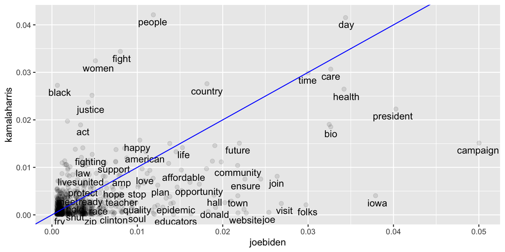

```r
ggplot(freq, aes(x=joebiden, y=kamalaharris))+
  geom_jitter(alpha=0.1, size=2)+
  geom_text(aes(label=word), check_overlap=TRUE, vjust=1.5)+
  geom_abline(color="blue")
```

```r
# Note the dark mass in the bottom left -- there's a lot of words that are used less frequently by both.
# In order to better see those, we can log transform our axes using the scales package

library(scales)
```

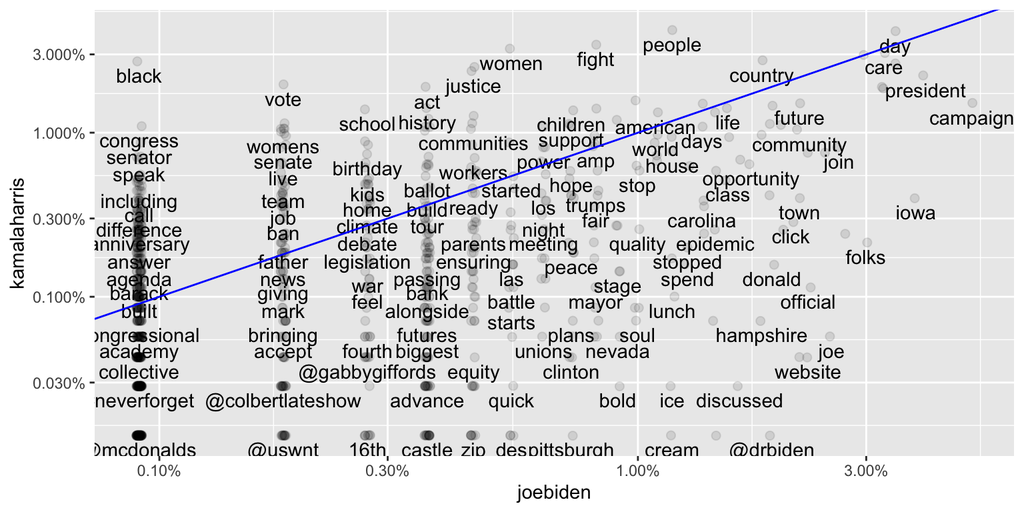

```r
ggplot(freq, aes(x=joebiden, y=kamalaharris))+
  geom_jitter(alpha=0.1, size=2)+
  geom_text(aes(label=word), check_overlap=TRUE, vjust=1.5)+
  scale_x_log10(labels=percent_format())+
  scale_y_log10(labels=percent_format())+
  geom_abline(color="blue")
```